# ChIPseq in Bioconductor exercises (part 3)

Rockefeller University, Bioinformatics Resource Centre

https://rockefelleruniversity.github.io/RU_ChIPseq/

## ChIPseq functional annotation and motif identification.

In this practical we will investigate the motifs and pathways associated with the Ebf1 transcription factor in proB-cells and B-cells.

- Pro-B-Cell Ebf1 data has been extracted from **GSM499030**.
- B-Cell Ebf1 data has been extracted from **GSE35857**.
- **Data/ebf1_proB.bed**
- **Data/ebf1_B.bed**
1. Load the ebf1 peaks for proB and B cells into R.
2. Find peaks in B cells which we also present in proB cells.
3. Extract the sequence 100bp (+/-50bp) around the geometric centre of these peaks, write to FASTA and submit to Meme-ChIP.

Results files from Meme-ChIP can be found [here](http://rockefelleruniversity.github.io/ebf1_motif/meme-chip.html)

4. Annotate common B cell peaks to genes with TSS set as +/- 500bp

[output not shown]

[output not shown]

5. Create a barplot of the occurrence of differing annotations (“Promoter”, “Distal Intergenic” and “other”).

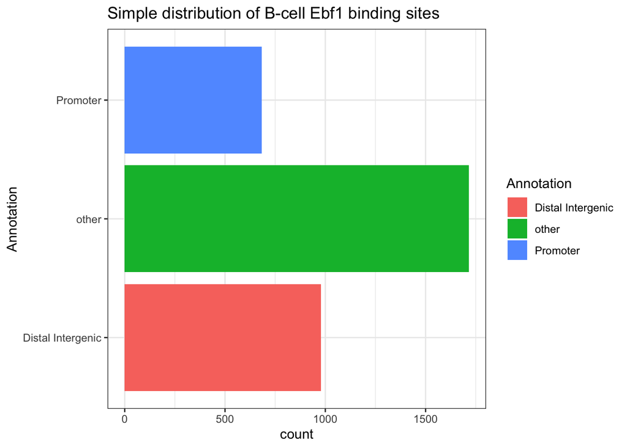

6. Perform a geneset enrichment test of genes with peaks in promoter against BP GO terms using clusterProfiler. Make a dotplot and an enrichment map of the results. Finally export the result.

[output not shown]

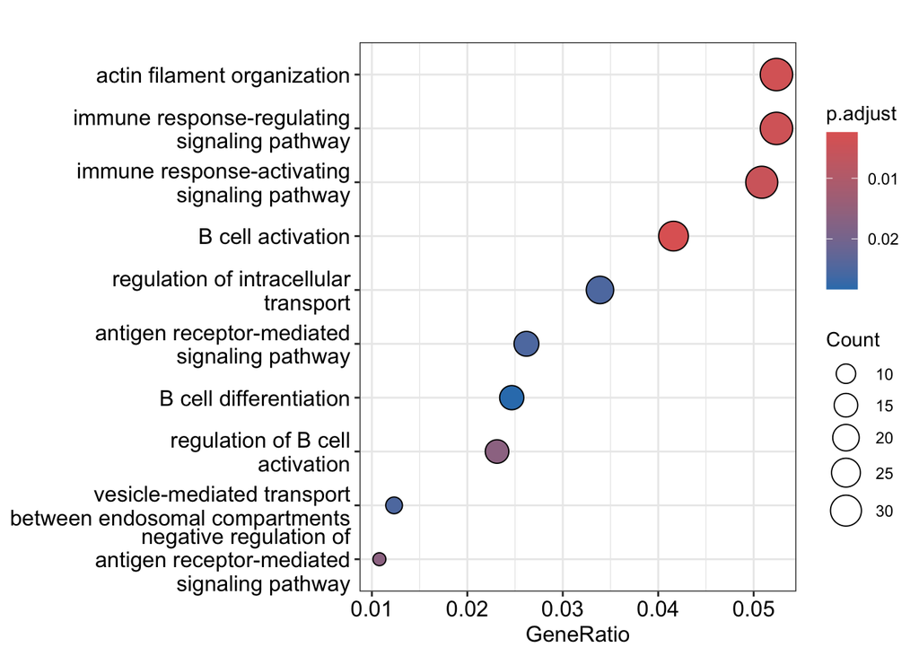

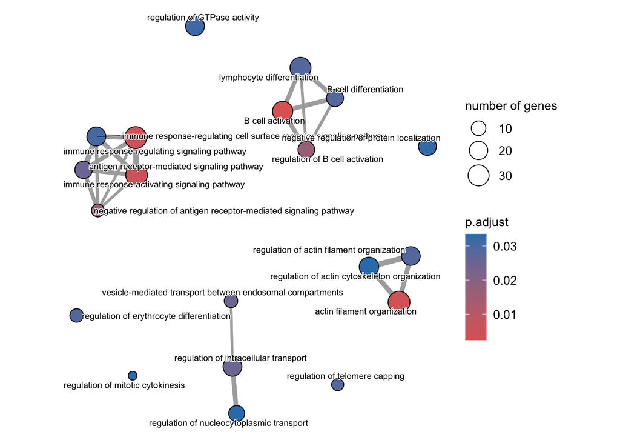

7. Identify Ebf1 peaks only in Bcells and Ebf1 peaks only in proB cells.

8 Using rGREAT identify the MSigDB Pathways enriched in Ebf1 peaks only in Bcells and Ebf1 peaks only in proB cells.

```
## [1] "GO"                               "Phenotype Data and Human Disease"
## [3] "Pathway Data"                     "Gene Expression"
## [5] "Regulatory Motifs"                "Gene Families"
```

[output not shown]

```
## [1] "PANTHER Pathway" "BioCyc Pathway"  "MSigDB Pathway"
```

```
##                                                             ID
## 1                       KEGG_B_CELL_RECEPTOR_SIGNALING_PATHWAY
## 2                                             PID_BCR_5PATHWAY
## 3                     REACTOME_INTERFERON_ALPHA_BETA_SIGNALING
## 4  REACTOME_DOWNSTREAM_SIGNALING_EVENTS_OF_B_CELL_RECEPTOR_BCR
## 5                                   REACTOME_SIGNALLING_BY_NGF
## 6                REACTOME_SIGNALING_BY_THE_B_CELL_RECEPTOR_BCR
## 7                                REACTOME_SIGNALING_BY_SCF_KIT
## 8                                         PID_RAC1_REG_PATHWAY
## 9                                       REACTOME_IMMUNE_SYSTEM
## 10                       REACTOME_PIP3_ACTIVATES_AKT_SIGNALING
##                                                                      name
## 1                                       B cell receptor signaling pathway
## 2                                                   BCR signaling pathway
## 3                       Genes involved in Interferon alpha/beta signaling
```

[output cut: 51 more lines]

```
## [1] "GO"                               "Phenotype Data and Human Disease"
## [3] "Pathway Data"                     "Gene Expression"
## [5] "Regulatory Motifs"                "Gene Families"
```

[output not shown]

```
## [1] "PANTHER Pathway" "BioCyc Pathway"  "MSigDB Pathway"
```

```
##                                                                           ID
## 1                                          REACTOME_METABOLISM_OF_PORPHYRINS
## 2                                                          PID_PDGFRBPATHWAY
## 3                             KEGG_NATURAL_KILLER_CELL_MEDIATED_CYTOTOXICITY
## 4                                                        REACTOME_HEMOSTASIS
## 5                                                     REACTOME_IMMUNE_SYSTEM
## 6                                                          PID_PI3KCIPATHWAY
## 7                                                           PID_BCR_5PATHWAY
## 8                                                    KEGG_TASTE_TRANSDUCTION
## 9                                      KEGG_FC_GAMMA_R_MEDIATED_PHAGOCYTOSIS
## 10 REACTOME_DEPOSITION_OF_NEW_CENPA_CONTAINING_NUCLEOSOMES_AT_THE_CENTROMERE
##                                                                                  name
## 1                                          Genes involved in Metabolism of porphyrins
## 2                                                        PDGFR-beta signaling pathway
## 3                                           Natural killer cell mediated cytotoxicity
```

[output cut: 51 more lines]